# Visuals for Association between Variables

### Adding lines to represent the relationship

We can add lines on the scatterplot to represent the relationship between the two variables using `geom_smooth()`. When using `geom_smooth()`, we can specify the method that we want to use for the line. If we want to draw a best straight line, we can specify `method="lm"` in the `geom_smooth()`. Note that “lm” stands for linear model.

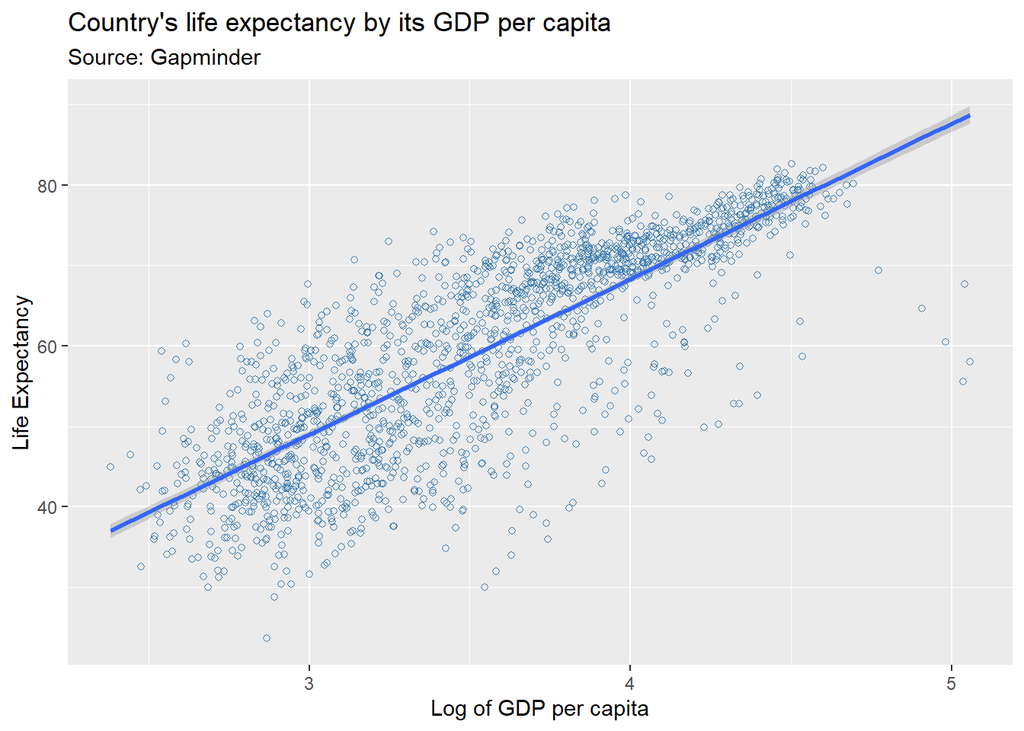

```r
# Specify the data and mapping
ggplot(data=gapminder2, mapping=aes(x=logGDP, y=lifeExp)) +

  # Draw scatterplot with the given options
  geom_point(color="steelblue",
             shape=1,
             size=1.5) +

  # Draw a line using linear model
  geom_smooth(method="lm") +

  # Change the axes labels, title, and subtitle
  labs(x="Log of GDP per capita",
       y="Life Expectancy",
       title="Country's life expectancy by its GDP per capita",
       subtitle="Source: Gapminder")
```

If the `method` is not specified when calling `geom_smooth()`, the smoothing technique will be used instead.

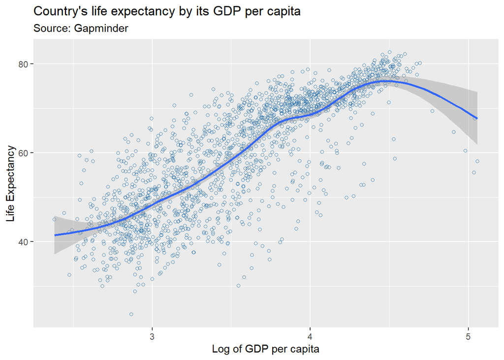

```r
# Specify the data and mapping
ggplot(data=gapminder2, mapping=aes(x=logGDP, y=lifeExp)) +
  geom_point(color="steelblue",
             shape=1,
             size=1.5) +

  # Draw a smooth line using LOESS
  geom_smooth() +

  # Change the axes labels, title, and subtitle
  labs(x="Log of GDP per capita",
       y="Life Expectancy",
       title="Country's life expectancy by its GDP per capita",
       subtitle="Source: Gapminder")
```

The blue line drawn using `geom_smooth()` is the expected y-value at the specified x-value, whereas the grey area between the blue line is the 95% confidence interval.

Here are some options you can use for `geom_smooth()`:

- `method`: Specify the method to form the line. If it is not specified, a smoothed nonparametric method is used.
- `formula`: May be used together with `method` to specify the formula used by the method.
- `color`: Color of the line.
- `se`: If `TRUE`, then the confidence interval will be shown. If `FALSE`, then it will not draw the confidence interval. The default value is `TRUE`.
- `level`: The level of the confidence interval. Default to `0.95`.

In the code below, we use `method="lm"` for linear model and set `formula=y~poly(x,3)` to specify that we are using the polynomial model with order 3. In this case, we try to form the line $y=\beta_0+\beta_1x+\beta_2x^2+\beta_3x^3$.

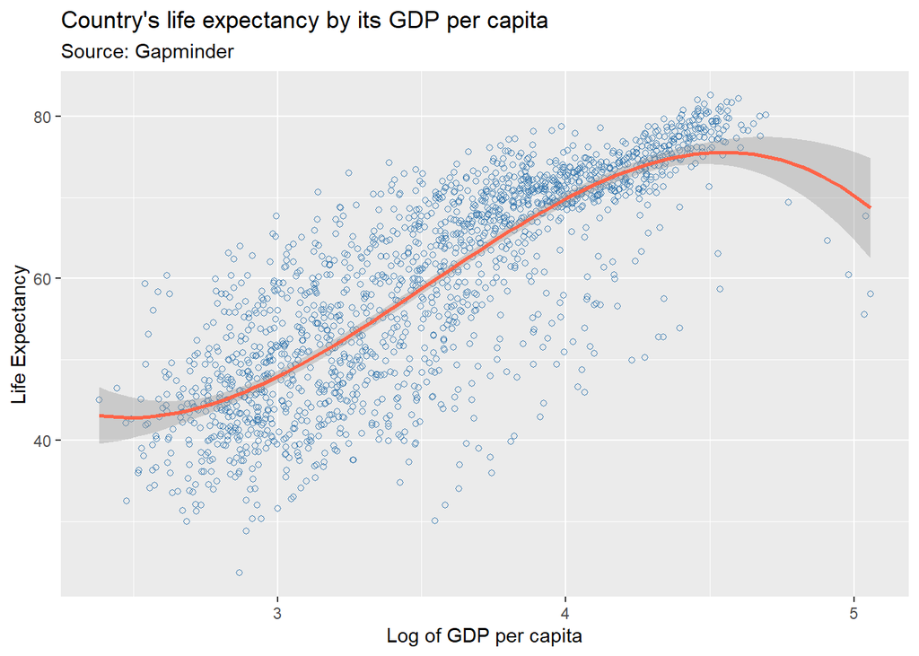

```r
# Specify the data and mapping
ggplot(data=gapminder2, mapping=aes(x=logGDP, y=lifeExp)) +
  geom_point(color="steelblue",
             shape=1,
             size=1.5) +

  # Draw a line using polynomial model of order 3
  geom_smooth(method="lm",
              formula=y~poly(x,3),
              color="tomato",
              se=TRUE,
              level=0.99) +

  # Change the axes labels, title, and subtitle
  labs(x="Log of GDP per capita",
       y="Life Expectancy",
       title="Country's life expectancy by its GDP per capita",
       subtitle="Source: Gapminder")
```

## Bubble Chart

Bubble chart is an extension of the scatterplot, where the size of the points corresponds to a third quantitative variable. To create a bubble chart, simply use `size` option in the `aes()` mapping whether global or local.

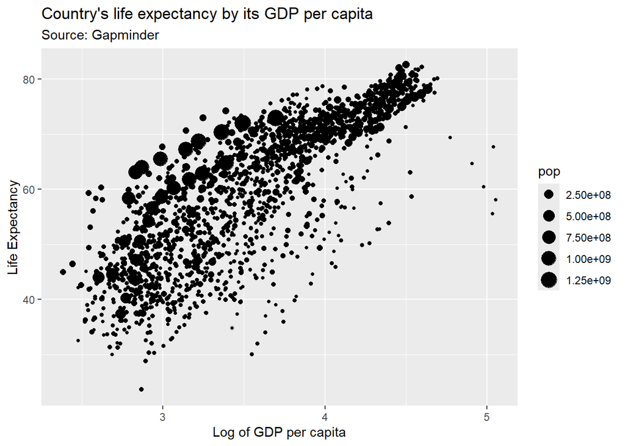

```r
# Specify the data and mapping, change size according to pop
ggplot(data=gapminder2, mapping=aes(x=logGDP, y=lifeExp,
                                    size=pop)) +

  # Draw scatterplot
  geom_point() +

  # Change the axes labels, title, and subtitle
  labs(x="Log of GDP per capita",
       y="Life Expectancy",
       title="Country's life expectancy by its GDP per capita",
       subtitle="Source: Gapminder")
```

The plot above can be difficult to see. Let’s change the color, fill, and transparency using the `color`, `fill`, and `alpha` arguments in `geom_point()`. The `shape=21` is a circle where we can modify its fill color.

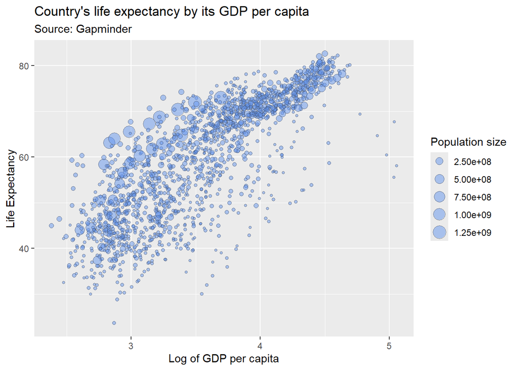

```r
# Specify the data and mapping, change size according to pop
ggplot(data=gapminder2, mapping=aes(x=logGDP, y=lifeExp,
                                    size=pop)) +

  # Draw scatterplot using the given options
  geom_point(color="grey20",
             fill="cornflowerblue",
             alpha=0.5,
             shape=21) +

  # Change the axes labels, title, and subtitle
  labs(x="Log of GDP per capita",
       y="Life Expectancy",
       title="Country's life expectancy by its GDP per capita",
       subtitle="Source: Gapminder",
       size="Population size")
```

## Marginal Plot

Marginal plot is another extension of scatterplot. In marginal plot, the marginal distribution or the distribution for each variable is added to the top and side of the plot in the form of histogram, boxplot, or kernel density plot.

To draw a marginal plot, we can use the `ggExtra` package and `ggMarginal()` function in it. First, let’s install and load the `ggExtra` package.

```r
# Install the package, run once per R version
install.packages("ggExtra")

# Load the package, run once per R session
library(ggExtra)
```

The `ggMarginal()` function is used outside of the `ggplot` chain. We first save the scatterplot into an object, then use `ggMarginal()` and use the object as the argument.

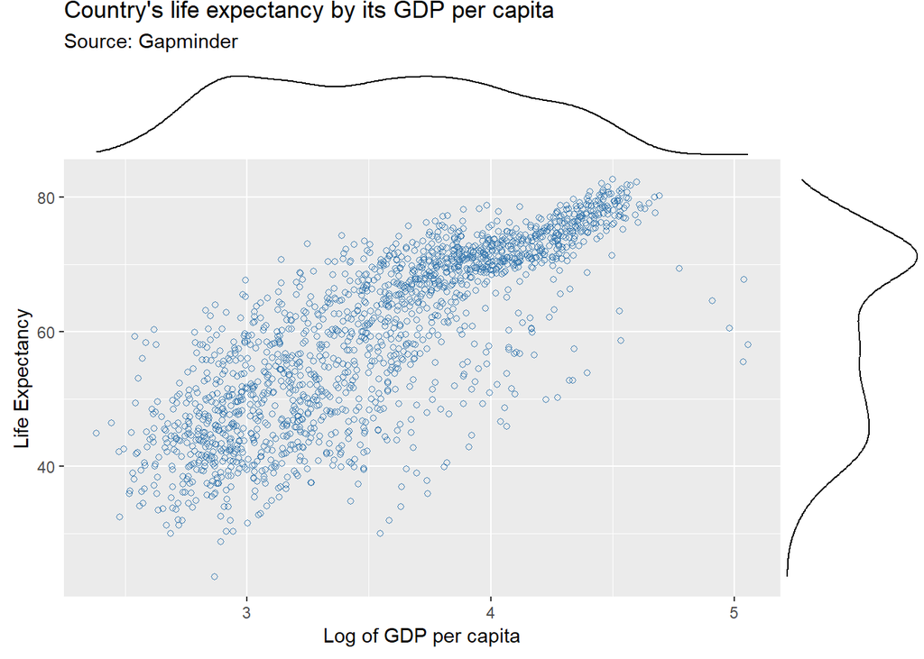

```r
# Save the ggplot object into a variable
plot <- ggplot(data=gapminder2, mapping=aes(x=logGDP, y=lifeExp)) +
  geom_point(color="steelblue", shape=1) +
  labs(x="Log of GDP per capita",
       y="Life Expectancy",
       title="Country's life expectancy by its GDP per capita",
       subtitle="Source: Gapminder",
       size="Population size")

# Draw the marginal plot
ggMarginal(plot)
```

Here are some further customization that we can use for `ggMarginal()`:

- `type`: Change the type of marginal plot used. It can either be `"density"`, `"histogram"`, `"boxplot"`, `"violin"`, or `"densigram"` (a combination of histogram and kernel density). Default value is `"density"`.
- `margins`: Choose whether to draw the marginal plot for both x and y variables, or either of them only. Either `"both"`, `"x"`, or `"y"`. Default value is `"both"`.
- `size`: Controls the relative size of the marginal plots compared to the scatterplot. The size is in ratio of the scatterplot. A size of 5 means the scatterplot is 5 times wider and 5 times taller.

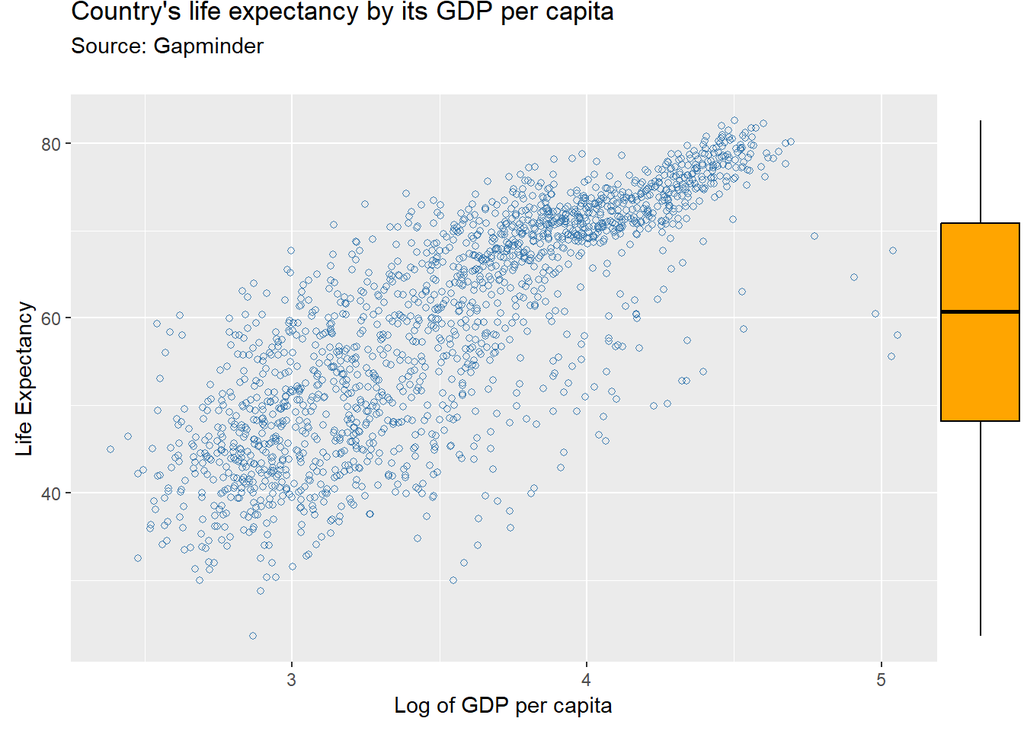

```r
# Save the ggplot object into a variable
plot <- ggplot(data=gapminder2, mapping=aes(x=logGDP, y=lifeExp)) +
  geom_point(color="steelblue", shape=1) +
  labs(x="Log of GDP per capita",
       y="Life Expectancy",
       title="Country's life expectancy by its GDP per capita",
       subtitle="Source: Gapminder",
       size="Population size")

# Draw the marginal plot
ggMarginal(plot, type="boxplot", margins="y", size=10, fill='orange')
```

Additionally, if the ggplot object contains grouping using colors, we can maintain the grouping by setting `groupColor=TRUE` and `groupFill=TRUE`.

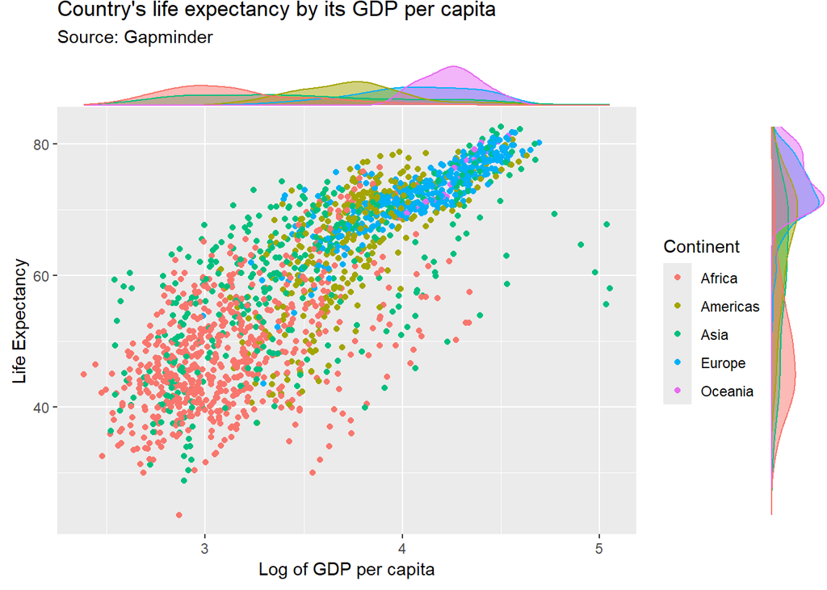

```r
# Save the ggplot object into a variable
plot <- ggplot(data=gapminder2, mapping=aes(x=logGDP, y=lifeExp, color=continent)) +
  geom_point() +
  labs(x="Log of GDP per capita",
       y="Life Expectancy",
       title="Country's life expectancy by its GDP per capita",
       subtitle="Source: Gapminder",
       size="Population size",
       color="Continent")

# Draw the marginal plot
ggMarginal(plot, type="density", groupColour=TRUE, groupFill=TRUE, size=10)
```

## Scatterplot Matrix

If we have three or more quantitative variables we may want to draw scatterplots for each pair of variables. This can be done using scatterplot matrix. However, there is no easy way to draw the scatterplot matrix using only `ggplot2` package. Thus, we can use `GGally` package and `ggpairs()` included in the package to draw the scatterplot matrix.

```r
# Install the package, run once per R version
install.packages("GGally")

# Load the package, run once per R session
library(GGally)
```

To use `ggpairs()`, we need to specify the data from where the variables or columns are. Then, if we are not using all the columns, we can specify which columns we want to use for the scatterplot matrix using the `columns` argument

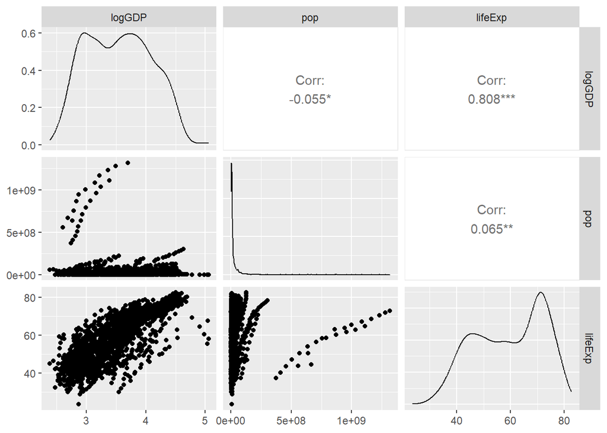

```r
# Draw scatterplot matrix for the specified columns only
ggpairs(data=gapminder2, columns=c("logGDP", "pop", "lifeExp"))
```

Since the scatterplots involving the population variable (`pop`) is difficult to see due to its size, we can try using a log transformation for it.

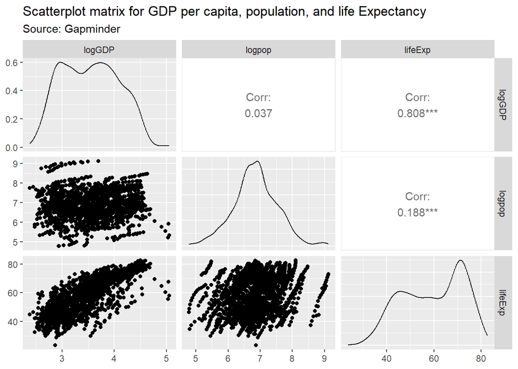

```r
# Add another column called logpop in the dataset
gapminder2 <- mutate(gapminder2, logpop=log10(pop))

# Draw scatterplot matrix for the specified columns only
ggpairs(data=gapminder2, columns=c("logGDP", "logpop", "lifeExp"),
        size=0.5) +

  # Add title and subtitle using labs()
  labs(title="Scatterplot matrix for GDP per capita, population, and life Expectancy",
       subtitle="Source: Gapminder")
```

There are a few things that the `ggpairs()` produces. First, it shows the kernel density estimate for each individual variables. Second, it draws the scatterplot matrix for each pair of variable. And third, it calculates the correlation for each pair of variables.

From the above plot, we can see that life expectancy has a positive relationship with the log of GDP per capita based on the scatterplot. That the correlation between life expectancy and log of GDP per capita is written as “`0.808***`”, showing that the correlation is statistically significant (i.e. significantly non-zero) after using the hypothesis test. On the other hand, the log of population exhibits weak association with life expectancy based on the scatterplot and correlation. We note however, that even though the correlation between the two is low (0.188), it is still significant due to the “`***`” shown. As for the log of GDP per capita and log of population, it seems that there is no relationship between the two and the correlation is low and not significantly different from zero.

## Correlation Plot

Correlation plot or matrix is another alternative to scatterplot matrix, where we have three or more variables and we want to see the association between them. However, in the case of scatterplot matrix, the visual becomes cumbersome and overly complicated when we have a lot of variables. The correlation plot simplifies this by only showing the correlation between each pair in a matrix form and give colors correspond to the value of the correlation.

One way to draw the correlation plot is to use `ggcorr()` function included in `GGally` package that we have previously used.

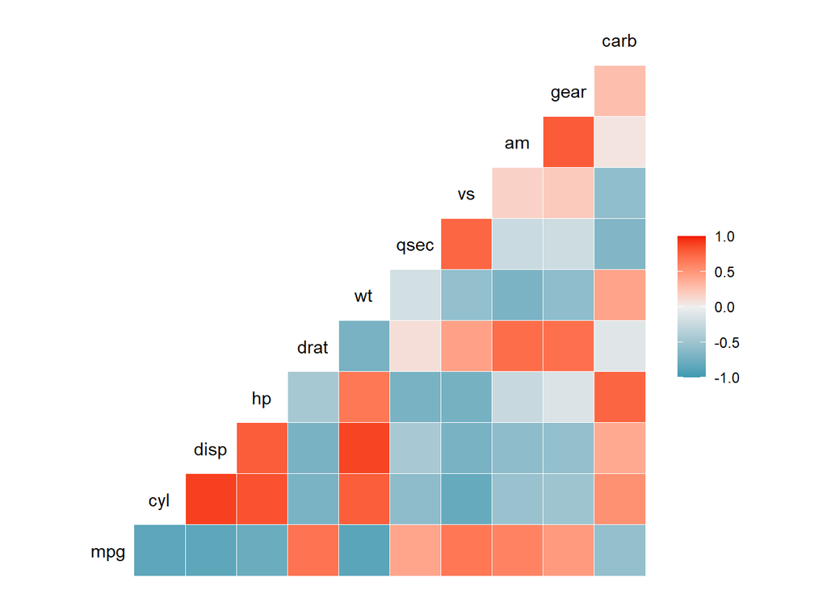

```r
# Draw correlation plot
ggcorr(mtcars)
```

Alternatively, we can use the `ggcorrplot()` function from the `ggcorrplot` package to draw a correlation plot. The `ggcorrplot()` requires us first to calculate the correlation matrix for the variables. We can use the `cor()` function in base R to do this.

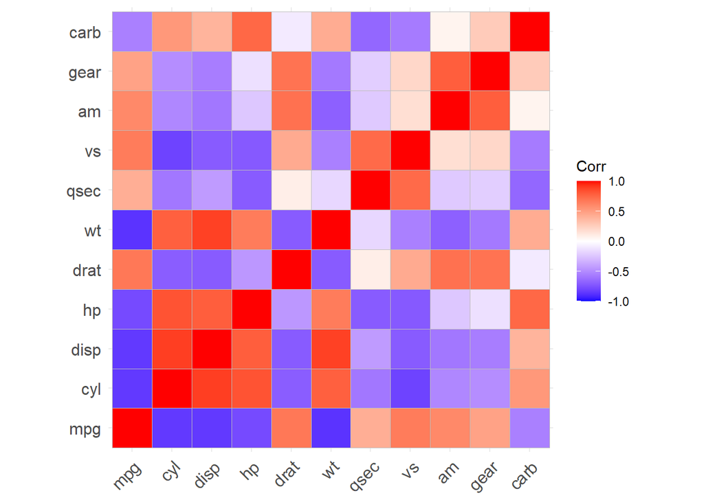

```r
# Install the package, run once per R version
install.packages("ggcorrplot")

# Load the package, run once per R session
library(ggcorrplot)

# Draw correlation plot
ggcorrplot(corr=cor(mtcars))
```

Here are some additional options that we can use for `ggcorrplot()`:

- `hc.order`: Set to be `TRUE` if we want to reorder the variables using hierarchical clustering. Default is `FALSE`.
- `type`: Set to be `"full"` if we want both upper and lower of the matrix/triangle, `"lower"` if we only want the lower triangle, and `"upper"` if we want upper triangle. Default is `"full"`.
- `lab`: Set to be `TRUE` if we want to add labels that show correlation value for each pair. Default is `FALSE`.

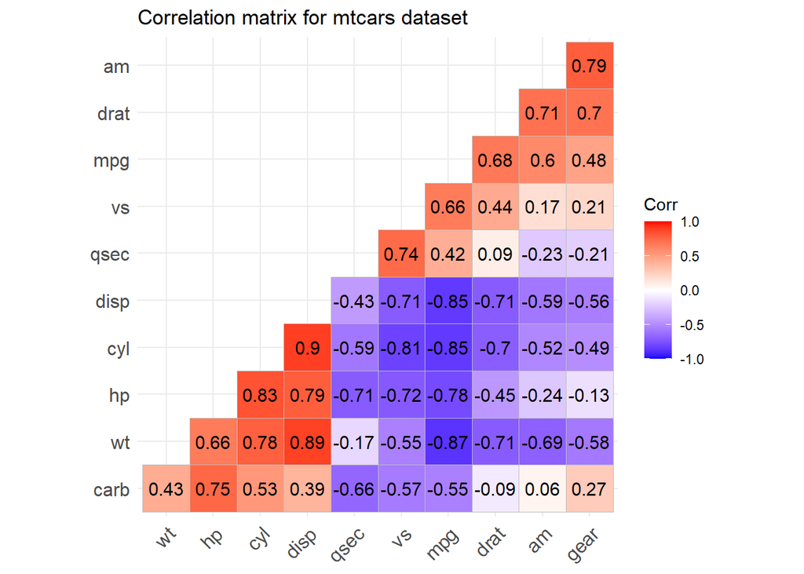

```r
# Draw correlation plot using the specified options
ggcorrplot(corr=cor(mtcars),
           hc.order=TRUE,
           type="lower",
           lab=TRUE) +

  # Add title using labs()
  labs(title="Correlation matrix for mtcars dataset")
```

From the plot, we can see that wt, hp, cyl and disp are positively related to each other. Similarly for vs, mpg, drat, am and gear. However, the two clusters seem to be negatively related.

## Conclusion

In this topic, we have explored some visuals we can use to display association and relationship between variables. We mainly use different forms of scatterplot to perform this task as they are easy to be read and understood. But we can also use correlation values and matrix to further show the association between variables.